# Moving Average Experiment

## Introduction/Background

I love statistics. I don’t mean numbers, although I suppose that’s wrapped up in it. I mean Statistics as in, the branch of mathematics. There’s one specific application of statistics that I love above all the rest – forecasting. It’s the most interesting application as well as the most difficult. Anyone can forecast today with little more than the click of a button using the extensive data analysis tools out there today, but to do so with the highest degree of accuracy requires a great deal of mathematical knowledge generally, and statistics knowledge specifically.

I’m also a big sports fanatic. There’s a lot to love: spectacle, drama, intensity, strategy, camaraderie, and more. I left one of my favorite parts out though – statistics. This time, I *do* mean statistics as in numbers. Sports provide an interminable, ever-changing flow of statistics with which there are potentially infinite analyses to be derived.

So I painted the big picture, now let me bring things back to the very small corner this little analysis will cover. I would like to be able to forecast NBA games with the highest degree of accuracy I can. NBA statistics are legion and there are relationships between the different statistics which greatly complicate this forecasting process. There is one stat though that applies across most of the others, and that is **Pace**, which is used to determine per-possession stats. Per-possession stats will give much greater accuracy to forecasting models over per-game stats. If you aren’t already familiar with this idea, the reasoning is actually fairly simple. Per-game statistics are heavily biased by overtime, and also vary quite a bit depending on how ‘fast’ or ‘slow’ each particular game is (e.g. ‘fast’ against teams like the Warriors or Rockets who play at a quick pace, ‘slow’ against teams like the Jazz who play at a slow pace). Because of this variance in Pace, per-game statistics aren’t as meaningful since they aren’t all based on a smaller common unit. Pace is based on number of possessions, which is scalable across over all games, all teams, and all years. This makes Pace and per-possession statistics the most unbiased[^1] statistics we can use, which will improve forecasting accuracy.

Now we can get to the meat of the analysis. My objective is to predict Pace in the most accurate way possible, to use as a foundation for the rest of the predictive statistics. But how to predict Pace?

## Data Exploration

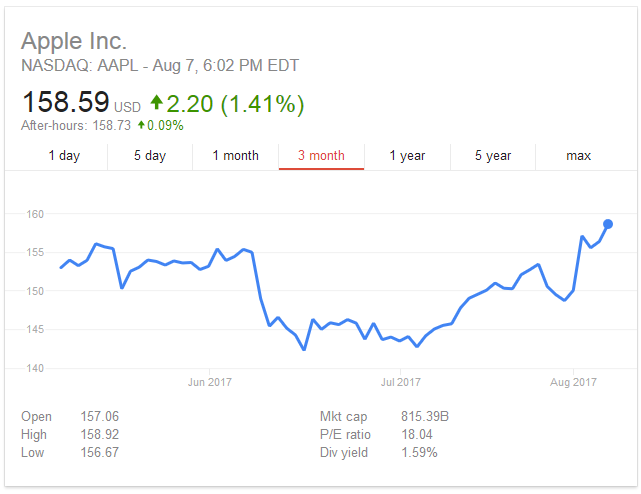

Looks kind of like a stock price chart right? We can use the similarities to our advantage and use a concept well-known to the stock price forecasting world – moving averages.

Moving averages are a critical component to financial forecasts. The reason why this is that things like stock price (and in our case, Pace) are *auto-correlated*, meaning that each stock price (or Pace) at time *n* is very closely related to the stock price right before it, at time *n-1*. There can also be yearly and/or seasonal adjustments you can include in these type of models as well (e.g. larger sales during the holidays). This family of methods/analysis is called [Time Series Analysis](https://onlinecourses.science.psu.edu/stat510/node/47) and can get much more complicated. I’m going to keep it simple and only focus on moving averages for this analysis.

## Moving Averages

There are many different types of moving averages (also sometimes referred to as rolling or running averages), but I’m going to focus on just the two most basic and most common ones you might see: Simple Moving Average (or SMA) and Exponential Moving Average (or EMA). There’s one commonality between the two types and one difference.

The commonality between both moving averages is that the average looks at a rolling ‘window’ of time. The window can be any length you want. For our example, it would be any *n* number of games immediately preceding the game we are hoping to predict. If the window we choose is 5 games, then only the last 5 games would count in our average. So for Game 6, Games 1 thru 5 would be the basis of the average. For Game 82, Games 77 thru 81 would be the basis. Each moving average also assigns a weight to each game.

The difference between the averages is the weight that is assigned to each game inside that window. For simple moving averages, each game is weighted equally. So if our window is 5 games, then each game will contribute 1/5 or 20% to the average. For exponential moving averages, the weights decrease exponentially the further back we go. So the most recent games count for more in the average than the later games. The degree to which they decrease depends on what’s called the “smoothing ratio”. This smoothing ratios that can be chosen are anything between 0 and 1, therefore are effectively infinite. The most common ratio that is used is 2/(n+1), n being the length of the window we have chosen. So with the example window of 5 games, the exponential smoothing ratio would be 2/6 or 33%.[^3]

## Experimental Design

There are 3 statistics that we’ll be judging the results by. These are **error**, **bias**, and **correlation**. In each case, these statistics are averages across all 30 teams. The fact that we are averaging across 30 teams introduces extra complexity to the analysis. This extra complexity matters, but does not ultimately change the outcome in this case, so to keep the analysis as simple as possible, I am going to ignore that extra complexity to keep the analysis simple.

Now let me briefly explain each of these 3 statistics we’re using and why they are important.

1. Error First, there are different applications of what ‘error’ could mean. The specific error term I’m using is called Root Mean Square Error or [RMSE](https://en.wikipedia.org/wiki/Root-mean-square_deviation). Essentially what the number actually means is how far off our predicted Pace is, on average. Error can be any number between 0 and infinity, but as you might expect, we want this statistic to be as small as possible.
2. Bias What this represents is the average amount per game that the moving averages over or underestimate Pace on average across all 30 teams. While the Error represents the spread of the data, Bias represents how closely the predictions ‘center’ around the true Pace values. So what we really want is for this statistic to be as close to zero as possible. If it were literally zero, that would make our statistic an *unbiased* estimator. Having an unbiased estimator is a highly desirable trait in statistical analysis. It isn’t always possible and in some cases a biased estimator will actually be a better predictor. At the very least though, we want to minimize the bias as much as possible, while also minimizing RMSE.
3. Correlation As with Error, there are different types of correlations that can be used. The statistic I will be using is actually an average of [3 different types of correlations](https://en.wikipedia.org/wiki/Correlation_and_dependence): Pearson (which is by far the most common, and what most people use), Kendall, and Spearman. And again, averaged across all 30 teams. Correlation can be any number between -1 and 1. In our case, we want our predicted Pace to be as close to the real value as possible, which would mean perfectly positively correlated and would have a correlation value of 1. So we want this statistic to be as large as possible.

A couple additional details I need to mention first before we take a look at the results.

1. The data I had available was for the last two seasons: 2015-2016 and 2016-2017. Keep in mind that this only covers the regular season, no playoffs or pre-season.
2. The intial ‘seed’ (i.e. prediction for the very first game of the 2015-2016 season, since we have no game data prior to that) used for every type of moving average was each team’s ending season average Pace for the 2014-2015 season, which I obtained from Basketball Reference.
3. For 2016-2017 (and would be the case for any additional year that is added), the seed for the season-long average was again set to the previous season’s average Pace. Take note that this is *only* for the season-long average. The moving averages do not need more than the single starting seed, since the moving averages *never* reset like the season-long average does.

Whew. OK, now we get to start the fun part – let the experimenting begin!

I chose to start with just a few window lengths to compare against the season-long average, to get a taste of what the different lengths will do for us: -regular season-long moving average. This is the ‘control’ group (i.e. what we are testing against) -Simple Moving Averages of length 5, 10, and 20 -Exponential Moving Averages of length 5, 10, and 20

In financial models, it’s quite common to see moving average lengths much longer than these I have chosen. However, in the context of an NBA season, I think around the last 20 games is the longest I would care to consider, and around the last 5 games is the shortest I would consider. The reasons for this are fairly simple – you don’t want to have too few games, otherwise your moving average can get easily skewed by outliers. And you don’t want too many games or else your moving average won’t be sensitive enough to changes teams have made, such as trades, injuries, etc. A balance between all of these considerations (not to mention the balance across all 30 teams and all years that we have data for) is what we are really looking to achieve here.

## The Results - Part II

We’re kind of splitting hairs here. I can’t say SMA9 is absolutely the best choice, but given my statistical background and experience, it does seem like the best choice to me in a way that I can’t really quantify.

## Conclusions

Looping back to my original goal of comparing these different moving averages to the season-long average, there is no question in my mind that SMA9 is a superior predictor of Pace.[^4] It’s also important to point out that while I think SMA9 is a clear improvement over season-long, the amount of improvement overall is pretty modest. I would *not* say SMA9 is a *good* predictor of Pace, but it *is* better than season-long. Feeding SMA9 as an input into another model with additional parameters may provide an even better predictor of Pace.[^5]

I will definitely revisit this analysis going forward as I’m able to add data from additional seasons to see how things change, or not, as the case may be. This will be especially important if I am building other metrics and models on top of SMA9, like I plan to.

After all of that work, the amount of improvement may not end up mattering as much as I might have initially hoped, but the experimenting it took to reach that conclusion was not only fun and interesting, but also taught me (and hopefully you!) quite a bit.

You can access and use all the code and data used in this analysis at my github [here](https://github.com/brandonsimonsen/nba-moving-averages).

[^1]: *bias* (and therefore *unbiased*) is an important statistical term and has multiple applications and meanings. A statistic being biased doesn’t necessarily make it always worse than an unbiased statistic. In this case however, it almost definitely would. https://en.wikipedia.org/wiki/Bias_of_an_estimator
[^2]: It’s also important at this point to point out that Pace is calculated by a formula which you can see here: https://www.basketball-reference.com/about/glossary.html
[^3]: You can see a better explanation of exponential moving averages calculations here: http://www.dummies.com/personal-finance/investing/stocks-trading/how-to-calculate-exponential-moving-average-in-trading/
[^4]: and not only SMA9, but I would choose almost any of these moving averages of season-long
[^5]: I plan to do just that myself, as well as exploring defense-adjusted Pace. I may have a Part II for this analysis that I will post at a later date.